# Exploring the Latest Dataset from Lyft-Bikes (06/2020)

## Preliminary Wrangling

```python
# import all packages and set plots to be embedded inline
import numpy as np
import pandas as pd
import matplotlib.pyplot as plt
import seaborn as sns
import datetime

%matplotlib inline
```

```python
df = pd.read_csv('202006-baywheels-tripdata.csv')
```

### Assessing the Data

```python
print(df.info())
df.head()
```

```
<class 'pandas.core.frame.DataFrame'>
RangeIndex: 158168 entries, 0 to 158167
Data columns (total 13 columns):
 #   Column              Non-Null Count   Dtype
---  ------              --------------   -----
 0   ride_id             158168 non-null  object
 1   rideable_type       158168 non-null  object
 2   started_at          158168 non-null  object
 3   ended_at            158168 non-null  object
 4   start_station_name  99220 non-null   object
 5   start_station_id    99220 non-null   float64
 6   end_station_name    97151 non-null   object
 7   end_station_id      97151 non-null   float64
 8   start_lat           158168 non-null  float64
 9   start_lng           158168 non-null  float64
 10  end_lat             157892 non-null  float64
 11  end_lng             157892 non-null  float64
 12  member_casual       158168 non-null  object
dtypes: float64(6), object(7)
memory usage: 15.7+ MB
None
```

|  | ride_id | rideable_type | started_at | ended_at | start_station_name | start_station_id | end_station_name | end_station_id | start_lat | start_lng | end_lat | end_lng | member_casual |
| --- | --- | --- | --- | --- | --- | --- | --- | --- | --- | --- | --- | --- | --- |
| 0 | 08A4A9F7315901F3 | electric_bike | 2020-06-03 16:37:10 | 2020-06-03 16:48:28 | NaN | NaN | NaN | NaN | 37.770000 | -122.40000 | 37.760000 | -122.420000 | casual |
| 1 | 844F9D906468C441 | electric_bike | 2020-06-03 12:22:47 | 2020-06-03 12:44:02 | NaN | NaN | NaN | NaN | 37.780000 | -122.49000 | 37.780000 | -122.460000 | casual |
| 2 | 0E441BF8A86C544E | electric_bike | 2020-06-02 17:37:43 | 2020-06-02 17:52:21 | Powell St at Columbus Ave | 487.0 | NaN | NaN | 37.800426 | -122.41095 | 37.790000 | -122.440000 | casual |
| 3 | CAFE64864422F475 | electric_bike | 2020-06-02 18:13:01 | 2020-06-02 18:48:30 | NaN | NaN | NaN | NaN | 37.760000 | -122.41000 | 37.770000 | -122.430000 | casual |
| 4 | 172957A20160D568 | electric_bike | 2020-06-03 15:16:06 | 2020-06-03 16:06:10 | Church St at Duboce Ave | 85.0 | 48th Ave at Cabrillo St | 521.0 | 37.769841 | -122.42921 | 37.772894 | -122.509079 | casual |

```python
df.rideable_type.unique()
```

```
array(['electric_bike', 'docked_bike'], dtype=object)
```

```python
df.member_casual.unique()
```

```
array(['casual', 'member'], dtype=object)
```

### Necesary changes

#### Quality

- Columns `started_at` and `ended_at` are not of type "date time"
- Columns `start_station_name` and `end_station_name` are not needed since we already have the `stations ids`
- Columns regarding longitude and latitude are not necessary for our analysis

### Cleaning the Data

```python
# create a copy of the dataset
df_clean = df.copy()
```

Change the columns `started_at` and `ended_at` to the typ datetime using `pd.to_datetime()` command

```python
df_clean.started_at = pd.to_datetime(df_clean.started_at)
```

```python
df_clean.ended_at = pd.to_datetime(df_clean.ended_at)
```

```python
# test that this worked
df_clean.dtypes
```

```
ride_id                       object
rideable_type                 object
started_at            datetime64[ns]
ended_at              datetime64[ns]
start_station_name            object
start_station_id             float64
end_station_name              object
end_station_id               float64
start_lat                    float64
start_lng                    float64
end_lat                      float64
end_lng                      float64
member_casual                 object
dtype: object
```

Drop all unnecesary columns of the dataset: start_station_name, end_station_name, start_lat, end_lat, start_lng, end_lng

```python
# drop the columns
df_clean.drop(columns=['start_station_name', 'end_station_name', 'start_lat', 'end_lat', 'start_lng', 'end_lng'],
              inplace=True)
```

```python
# Test columns where successfully dropped
df_clean.info()
```

[output not shown]

Feature Engineering:

- create a feature that reflects the duration of a ride
- create a feature that shows the weekday the bike was rented
- create a feature that shows the time the bike was rented

```python
df_clean['ride_dur'] = df_clean.ended_at - df_clean.started_at
df_clean['ride_dur'].describe()
```

```
count                    158168
mean     0 days 00:26:56.991003
std      0 days 05:08:18.265074
min           -1 days +23:45:57
25%             0 days 00:07:22
50%             0 days 00:13:15
75%             0 days 00:23:21
max            25 days 20:33:06
Name: ride_dur, dtype: object
```

No ride should be negative, that is why we will drop all the rows containing negative times. Furthermore, it looks like there are some outliers. For this we will look at the distribution

```python
# get rid of all the negative values
df_clean = df_clean.loc[df_clean.ride_dur >= '0']
```

```python
# transform the date time factor to minutes as a float
df_clean.ride_dur = (df_clean.ride_dur / np.timedelta64(1, 's'))/60
```

```python
# get the summary statistics
df_clean.ride_dur.describe()
```

```
count    158133.000000
mean         26.956052
std         308.338250
min           0.000000
25%           7.366667
50%          13.250000
75%          23.350000
max       37233.100000
Name: ride_dur, dtype: float64
```

```
(0.0, 5e-06)
```

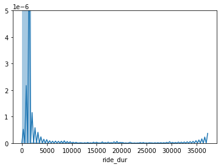

```python
# take a look at the distribution
sns.distplot(df_clean.ride_dur, bins=20)
plt.ylim((0,0.000005))
```

```python
# Drop all outliers: identify the 99 percentile and drop all values above
np.percentile(df_clean.ride_dur, 99)
```

```
126.35
```

```python
# Drop all values above the 99 percentile
df_clean = df_clean.loc[df_clean.ride_dur < 126.35]
```

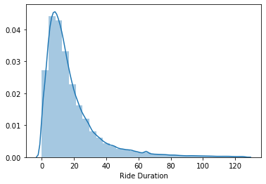

```python
# Test: get a view of the distribution of the revised dataset
sns.distplot(df_clean.ride_dur, bins=30)
plt.xlabel('Ride Duration')
```

Create a new feature that shows the day of the week the bike was rented

```python
# create a feature that shows the weekday the bike was rented
df_clean['week_day'] = df_clean['started_at'].dt.dayofweek
```

```python
# test the new created feature
df_clean['week_day'].value_counts()
```

```
5    25739
1    23670
6    22498
2    21999
0    21937
4    21456
3    19251
Name: week_day, dtype: int64
```

```python
# Create a dictionary for the days of the week
days_dict = {0: 'Monday',
            1: 'Tuesday',
            2: 'Wednesday',
            3: 'Thursday',
            4: 'Friday',
            5: 'Saturday',
            6: 'Sunday'}
```

```python
# replace the numbers with categories
df_clean['week_day'].replace(days_dict, inplace=True)
```

```python
# test new feature worked
df_clean.sample(5)
```

[output not shown]

```python
# change data type to category since the days follow an order
day_order = ['Monday',
             'Tuesday',
             'Wednesday',
             'Thursday',
             'Friday',
             'Saturday',
             'Sunday']
ordered_day = pd.api.types.CategoricalDtype(ordered=True, categories=day_order)
df_clean['week_day'] = df_clean['week_day'].astype(ordered_day)
```

```python
# test
df_clean.week_day.dtypes
```

```
CategoricalDtype(categories=['Monday', 'Tuesday', 'Wednesday', 'Thursday', 'Friday',
                  'Saturday', 'Sunday'],
                 ordered=True)
```

The new feature `week_day` is ready for the analysis

Create a new feature that shows the hour of the day (24 hours) a bike is rented

```python
# create the new feature with the hour of the day a bike is rented
df_clean['hour_of_day'] = df_clean.started_at.dt.hour
```

```python
# test the new feature was created successfully
df_clean.hour_of_day.value_counts().sort_index()
```

```
0      1115
1       737
2       607
3       503
4       548
5       920
6      2262
7      4275
8      5438
9      6052
10     6920
11     8704
12    10722
13    11450
14    12403
15    13022
16    13873
17    15822
18    14535
19    11622
20     6957
21     3759
22     2606
23     1698
Name: hour_of_day, dtype: int64
```

```python
# make a category variable for the rest the analysis
df_clean.hour_of_day.value_counts().sort_index().index
```

```
Int64Index([ 0,  1,  2,  3,  4,  5,  6,  7,  8,  9, 10, 11, 12, 13, 14, 15, 16,
            17, 18, 19, 20, 21, 22, 23],
           dtype='int64')
```

```python
order_hour = [0,  1,  2,  3,  4,  5,  6,  7,  8,  9, 10, 11, 12, 13, 14, 15, 16,
            17, 18, 19, 20, 21, 22, 23]
hour_ordered = pd.api.types.CategoricalDtype(ordered=True, categories=order_hour)
df_clean.hour_of_day = df_clean.hour_of_day.astype(hour_ordered)
```

```python
# test new feater was created successfully
df_clean.sample(5)
```

|  | ride_id | rideable_type | started_at | ended_at | start_station_id | end_station_id | member_casual | ride_dur | week_day | hour_of_day |
| --- | --- | --- | --- | --- | --- | --- | --- | --- | --- | --- |
| 120551 | 9F30B651BEBA244E | docked_bike | 2020-06-13 14:39:59 | 2020-06-13 14:45:27 | 370.0 | 3.0 | member | 5.466667 | Saturday | 14 |
| 14241 | B121C28D1D62380F | electric_bike | 2020-06-25 13:25:23 | 2020-06-25 13:37:19 | 61.0 | 120.0 | casual | 11.933333 | Thursday | 13 |
| 3139 | F0E4675848FE9D54 | electric_bike | 2020-06-13 09:59:05 | 2020-06-13 10:31:12 | 104.0 | 377.0 | casual | 32.116667 | Saturday | 9 |
| 94648 | 050CB072D5EE7FD8 | docked_bike | 2020-06-18 18:04:00 | 2020-06-18 18:30:41 | 294.0 | 301.0 | casual | 26.683333 | Thursday | 18 |
| 145249 | 4F4F366FE199FA6C | docked_bike | 2020-06-01 17:17:48 | 2020-06-01 17:38:23 | 138.0 | 138.0 | member | 20.583333 | Monday | 17 |

New variable hour_of_day was created successfully and is ready to be analyzed

### What is/are the main feature(s) of interest in your dataset?

The main features of interest are those who help explain the variation in the *duration of the ride* (`ride_dur`). (To be explored) a possible second dependent variable could be the *type of bike* (`rideble_type`), also figuring out what does predict the choice

## Univariate Exploration

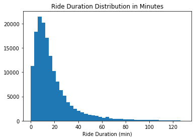

```python
# take a deeper look at the distribution of the ride_dur variable
bins_dur_size = 3 # bins the size of 5 min
bins_dur = np.arange(0, df_clean.ride_dur.max()+bins_dur_size, bins_dur_size)

plt.hist(data=df_clean, x='ride_dur', bins=bins_dur)
plt.xlabel('Ride Duration (min)')
plt.title('Ride Duration Distribution in Minutes');
```

The distribution is right skewed. Be careful when comparing to other variables since most of the observations are between 0 and 30 min

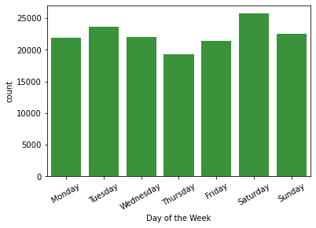

```python
# take a look to the distribution of days of the week
base_color_day = sns.color_palette()[2]

sns.countplot(data=df_clean, x='week_day', color=base_color_day)
plt.xticks(rotation=30)
plt.xlabel('Day of the Week');
```

There is a nice variation in the renting day. We see a peak on saturday

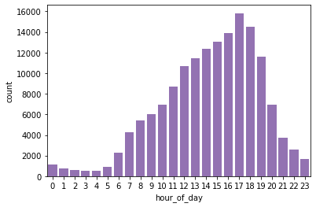

```python
# take a look to the hour
base_color_hour = sns.color_palette()[4]

sns.countplot(data=df_clean, x='hour_of_day', color=base_color_hour);
```

we see a somewhat left skewed distribution with its peak at 17 o'clock

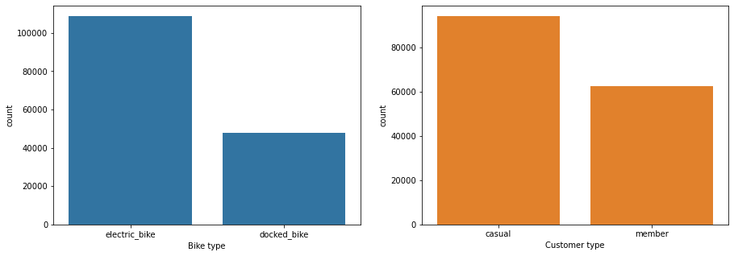

```python
# take a look at the distribution of the type of the bike and the customer
plt.figure(figsize=[15,5])

# choose colors for the two features
base_color_btype = sns.color_palette()[0]
base_color_ctype = sns.color_palette()[1]

# plot the bars
plt.subplot(1,2,1)
sns.countplot(data=df_clean, x='rideable_type', color=base_color_btype)
plt.xlabel('Bike type')

plt.subplot(1,2,2)
sns.countplot(data=df_clean, x='member_casual', color=base_color_ctype)
plt.xlabel('Customer type')
```

given this results I expect the customer type to have an explanation power on the ride duration

## Bivariate Exploration

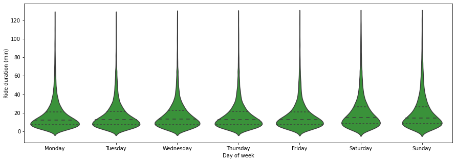

```python
# violin plot between ride duration and day of week
plt.figure(figsize=[15, 5])
sns.violinplot(data=df_clean, x='week_day', y='ride_dur', inner='quartile', color=base_color_day)
plt.xlabel('Day of week')
plt.ylabel('Ride duration (min)')
```

During the weekdays (mon-fri) is the distribution very similar with very similar means. Only during the weekends (sat-sun) we see an increase in the mean

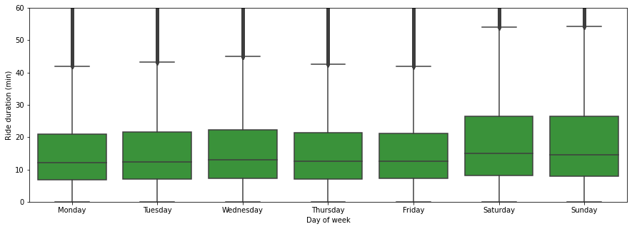

```python
# boxplots between ride duration and day of week
plt.figure(figsize=[15, 5])
sns.boxplot(data=df_clean, x='week_day', y='ride_dur', color=base_color_day)

# zoom in
plt.ylim((0,60))
plt.xlabel('Day of week')
plt.ylabel('Ride duration (min)');
```

the distribution of the ride duration for each day of the week returns pretty much the original distribtuion of the ride duration. We only see minimal change during weekends. Possibly we need to create a new feature `weekday-weekend`.

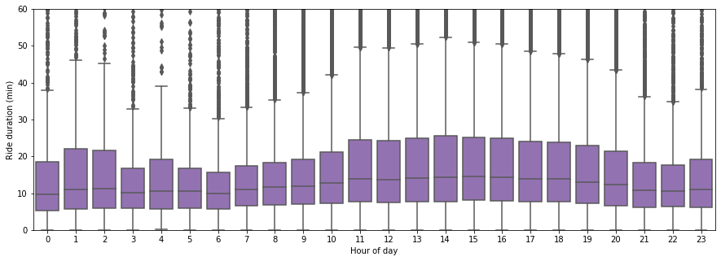

```python
# boxplots between ride duration and the hour of the day
plt.figure(figsize=[15, 5])
sns.boxplot(data=df_clean, x='hour_of_day', y='ride_dur', color=base_color_hour)

# zoom in
plt.ylim((0,60))
plt.xlabel('Hour of day')
plt.ylabel('Ride duration (min)');
```

the behavior of the ride duration seems to be pretty close to the behavior of the distribution of the hour of the day (when the bike is rented). I want to see the average ride duration besides de median

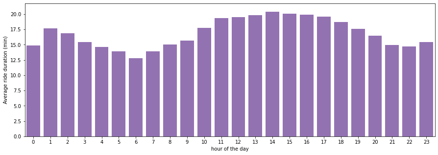

```python
# Average ride duration and the hour of the day
plt.figure(figsize=[15, 5])
sns.barplot(data=df_clean, x='hour_of_day', y='ride_dur', color=base_color_hour, errwidth=0)
plt.ylabel('Average ride duration (min)')
plt.xlabel('hour of the day')
```

we see here a different behavior in the variations compare to the number of bikes that are rented at each hour of the day

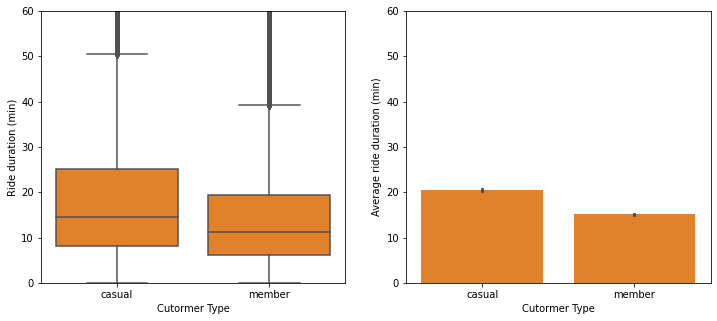

```python
# check the relation between ride duration and the customer type
plt.figure(figsize=[12,5])

plt.subplot(1,2,1)
sns.boxplot(data=df_clean, x='member_casual', y='ride_dur', color=base_color_ctype)
# zoom in
plt.ylim((0,60))
plt.xlabel('Cutormer Type')
plt.ylabel('Ride duration (min)')

plt.subplot(1,2,2)
sns.barplot(data=df_clean, x='member_casual', y='ride_dur', color=base_color_ctype)
# zoom in
plt.ylim((0,60))
plt.xlabel('Cutormer Type')
plt.ylabel('Average ride duration (min)')
```

It seems like the type of customer explain some of the variation in the ride duration. Nuw let's see how the independent variables interact with each other

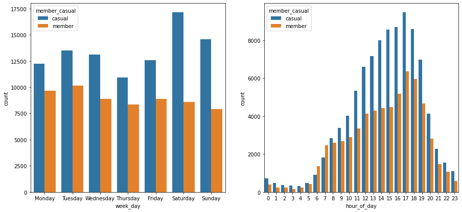

```python
# define the variables to compare
plt.figure(figsize=[15,15])

plt.subplot(2,2,1)
sns.countplot(data=df_clean, x='week_day', hue='member_casual')

plt.subplot(2,2,2)
sns.countplot(data=df_clean, x='hour_of_day', hue='member_casual')
```

No big surprise as there are more casual customers than members. The multivariate approach is going to be much more interesting

Finally, I want to see how the ride duration time depends on the type of bike

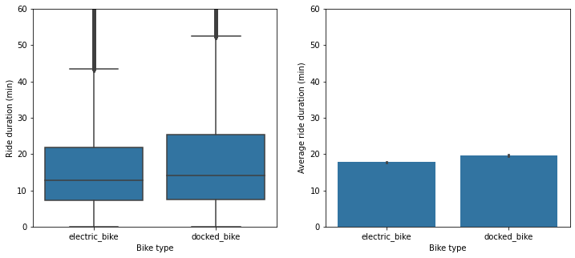

```python
plt.figure(figsize=[12,5])

plt.subplot(1,2,1)
sns.boxplot(data=df_clean, x='rideable_type', y='ride_dur', color=base_color_btype)
# zoom in
plt.ylim((0,60))
plt.xlabel('Bike type')
plt.ylabel('Ride duration (min)')

plt.subplot(1,2,2)
sns.barplot(data=df_clean, x='rideable_type', y='ride_dur', color=base_color_btype)
# zoom in
plt.ylim((0,60))
plt.xlabel('Bike type')
plt.ylabel('Average ride duration (min)');
```

## Multivariate Exploration

First, let us see how the ride duration changes depending on the day and the type of customer

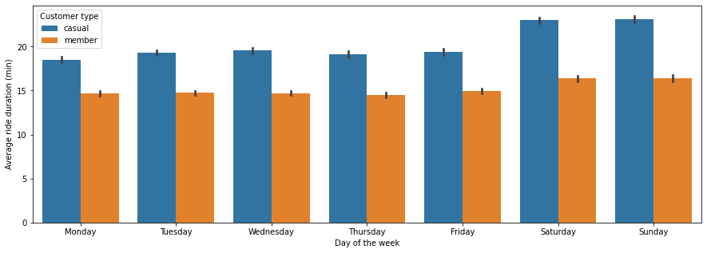

```python
plt.figure(figsize=[15,5])

colors = {'casual': base_color_btype, 'member': base_color_ctype}
sns.barplot(data=df_clean, hue='member_casual', palette=colors, x='week_day',
                y='ride_dur')
plt.ylabel('Average ride duration (min)')
plt.xlabel('Day of the week')
plt.legend(title='Customer type');
```

It seems like casual customer use the bikes on average for a longer time than members. The spikes over the weekends seems to increase on average more for casual customers.

Now I want to see the variation of the ride duration depending on the customer type and the time of the day

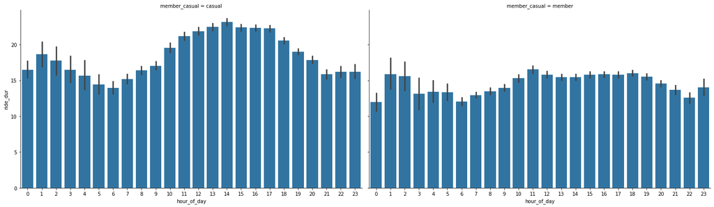

```python
g = sns.FacetGrid(data=df_clean, col='member_casual',
                  height=6, aspect=1.7)
g.map(sns.barplot, 'hour_of_day', 'ride_dur');
```

The variation in the average duration of a ride in a given hour of the day is strongly affected by the type of customer.

Finally let us analyse the time of the day and the day the bikes are rented

[figure not shown]

```python
g = sns.FacetGrid(data=df_clean, col='week_day',
                  height=6, aspect=1.7, col_wrap=7)
g.map(sns.barplot, 'hour_of_day', 'ride_dur');
```

the variation during week days (Mon-Fri) is pretty similar while the weekends tend to be more variable. **In this case I will create a new feature, which is called `is_weekend`**

```python
# create new feature is_weekend
df_clean['is_weekend'] = ((df_clean.week_day == 'Saturday') ^ (df_clean.week_day == 'Sunday'))
```

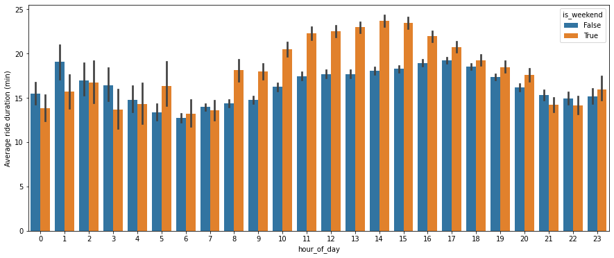

```python
# take a look to changes in the ride duration depending on is_weekend and time of the day
plt.figure(figsize=[15,6])
sns.barplot(data=df_clean, x='hour_of_day', y='ride_dur', hue='is_weekend')
plt.ylabel('Average ride duration (min)');
```

### Summary:

All this findings remain as hypothesis and need to be tested to confirm any statistical significance. Furthermore it would be very interesting to build a prediction model for the duration of the ride. However, there are many more variables that need to be included, for example the weather, the neighborhood, the month, the number of bikes availables, the population density and so on. This remains open for further research